# House Pricing Prediction

## GROUP 12

*Arnaud Barral*

*Jeanne Barthélemy*

*Alice Dumay*

*Maxime Bouthors*

### Imports

```python
#Libraries
import numpy as np # linear algebra
import pandas as pd # data processing, CSV file I/O (e.g. pd.read_csv)
import seaborn as sns
import matplotlib.pyplot as plt
from sklearn.compose import ColumnTransformer
from sklearn.pipeline import Pipeline
from sklearn.impute import SimpleImputer
from sklearn.preprocessing import OneHotEncoder, OrdinalEncoder
from sklearn.ensemble import RandomForestRegressor
from sklearn.ensemble import GradientBoostingRegressor
from sklearn.metrics import mean_absolute_error
from sklearn.metrics import roc_curve, auc
from sklearn.model_selection import cross_val_score
from sklearn.model_selection import cross_validate
from sklearn.model_selection import GridSearchCV
from sklearn.svm import SVR
from sklearn.linear_model import LogisticRegression
from sklearn import preprocessing

test = pd.read_csv("test.csv")
train = pd.read_csv("train.csv")
print("Import complete")
```

```
Import complete
```

### 1. Data preparation

#### Data exploration

We have **80** features, counting the indexing in, for **1** label: the house pricing ($).

The features are diverse in there format (integers, strings, floats), and there are even missing values for some entries (NaN).

The training data has **1,200** entries.

#### Task identification

As the label is a price, there is no reason to consider it as a classification task. Even though it is possible to do so by grouping the prices into slices, we do not think this is relevant here. That is why we consider this problem as a **regression** one.

#### Correlation

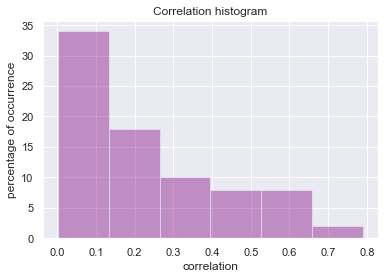

```python
train_cat = train.copy()
str_features = [col for col in train.columns if train[col].dtype == 'object']
for feature in str_features:
    train_cat[feature]=train_cat[feature].astype('category').cat.codes
correlations = train_cat.corr()["SalePrice"].drop(["SalePrice"]).abs()
sns.set(style="darkgrid")
ax = sns.distplot(correlations.values, kde=False, color="purple")
ax.set_title("Correlation histogram")
ax.set_xlabel("correlation")
ax.set_ylabel("percentage of occurrence")
print()
```

The entry indexing, that is entirely uncorrelated with the Sale Price, has a correlation of 0.02. Many other features achieve this same kind of values.

These features thus do not not seem relevant in the learning task. We simply remove them from the data. We chose a threshold of 0.1. This value of 0.1 is quite arbitrary, and we may loose information, but as 1/3 of the features are removed, the learning process will surely be a lot faster. And we probably do not loose that much information through this 'pruning' process.

```python
selected_features = correlations.index.to_numpy()[np.array(correlations.values) > 0.1]

# keep only the selected features
train_clean = train[selected_features].copy()
test_clean = test[selected_features].copy()
```

#### Missing value handling

It turns out there are missing values in the data that we need to handle. There are even features that have a rather big proportion of them:

```python
nan_count = train_clean.isna().sum()
print("NaN values count")
print(nan_count[nan_count.index[nan_count.to_numpy().nonzero()]])
```

```
NaN values count
LotFrontage     210
MasVnrArea        6
BsmtQual         32
BsmtCond         32
BsmtExposure     33
BsmtFinType2     33
FireplaceQu     564
GarageType       67
GarageYrBlt      67
GarageFinish     67
GarageQual       67
GarageCond       67
Fence           973
dtype: int64
```

We chose to keep features with missing values provided they had a big enough correlation. Note that the correlation derivation takes the missing values into account.

The missing values are due to 2 things:

- Description of a missing thing. We just need to create a new category "None" to indicate there is nothing.
- Measure of a missing thing. We can simply replace the NaN values by zeros since their absence correpond to 0 length/area.

| Feature | Solution |
| --- | --- |
| LotFrontage | NaN replaced by Zeros |
| MasVnrArea | NaN replaced by Zero |
| FireplaceQu | New category "None" |
| Fence | New category "None" |
| Bsmt* | New category "None" |
| Garage* | New category "None" |

* Contains all subcategories starting with this name

First, we thought about replacing these missing values by the mean value or the most frequent value (depending on whether the feature is numerical or categorical). However, we found out it was more relevant to explore these values more individually and come out with more adapted solutions. As an example, it would not make sense to replace the missing values of the lot frontage by the average value since the information of "*not having a lot frontage*" would be lost.

```python
# Filling missing values
train_clean["MasVnrArea"].astype('float64')
train_clean["MasVnrArea"].astype('float64')
train_clean["MasVnrArea"] = train_clean["MasVnrArea"].fillna(0.)
test_clean["MasVnrArea"] = test_clean["MasVnrArea"].fillna(0.)
train_clean["LotFrontage"] = train_clean["LotFrontage"].fillna(0.)
test_clean["LotFrontage"] = test_clean["LotFrontage"].fillna(0.)
NaN_features = ["FireplaceQu", "Fence", "BsmtExposure", "BsmtQual", "BsmtCond", "BsmtFinType2",
               "GarageType", "GarageYrBlt", "GarageFinish", "GarageQual", "GarageCond"]
for feature in NaN_features:
    train_clean[feature] = train_clean[feature].fillna("None")
    test_clean[feature] = test_clean[feature].fillna("None")
```

#### Feature grouping

The only relevant grouping we found was to add the number of half/full bathrooms with respect to their location (basement or above grade). This way we will have the information of the total number of *full bathrooms* or *half bathrooms* respectively in the house.

```python
# combining features

train_aug = train_clean
train_aug.loc[:, "TotFullBath"] = train.loc[:, "FullBath"] + train.loc[:, "BsmtFullBath"]
train_aug.loc[:, "TotHalfBath"] = train.loc[:, "HalfBath"] + train.loc[:, "BsmtHalfBath"]

test_aug = test_clean
test_aug.loc[:, "TotFullBath"] = test.loc[:, "FullBath"] + test.loc[:, "BsmtFullBath"]
test_aug.loc[:, "TotHalfBath"] = test.loc[:, "HalfBath"] + test.loc[:, "BsmtHalfBath"]
```

#### Data Normalization

We used data normalization for testing models sensitive to it (like SVM), but eventually it became unnecessary for tree decision-based models (what we eventually selected), producing even worse results in practice. That is why we do not normalize the data here.

#### Feature/Label separation

We also cast the categorical data into strings in this step. That is why we separate the numerical and categorical features here.

```python
# select numerical features
numerical_cols = [col for col in train_clean.columns
                  if train_clean[col].dtype == 'int64'
                  or train_clean[col].dtype == 'float64']
print("Number of columns that are numerical: " + str(len(numerical_cols)))
print()
# select categorical features
categorical_cols = [col for col in train_clean.columns
                    if train_clean[col].dtype == 'object']
print("Number of columns that are categorical: " + str(len(categorical_cols)))
```

```
Number of columns that are numerical: 28

Number of columns that are categorical: 27
```

```python
# Label/feature separation
trainy = train.loc[:,['SalePrice']]
trainX = train_aug
trainX[categorical_cols] = trainX[categorical_cols].astype(str)

testy = test.loc[:,['SalePrice']]
testX = test_aug
testX[categorical_cols] = testX[categorical_cols].astype(str)
```

#### Categorical features encoding

We need to consider the categorical values as numbers in the learning algorithms. We have two choices:

- **One Hot Encoding**
- **Ordinal Encoding**

We eventually chose **Ordinal Encoding** since we found out it is more relevant for decision tree-based models. The **One Hot Encoding** also considerably increases the number of features, what is not desirable.

> **Note**: We nonetheless used **One Hot Encoding** for *Logistic Regression* in model selection for way better results.

```python
# Oridinal encoder initialization
encoder = OrdinalEncoder()
tot = pd.concat([trainX, testX])
encoder.fit(tot)
```

```
OrdinalEncoder(categories='auto', dtype=<class 'numpy.float64'>)
```

> **Note**: We use the test set for initializing the encoder since some categorical values only appear in the test set. We would have errors not doing so when encoding the test data afterward. It may sound like cheating using the test set here, but it is only about considering the possible values that can be taken for a given categorical feature. We are suppose to have access to this information, but it would be laborious doing so manually. Concatenating the train and test set is just a trick to avoid this.

### 2. Model selection

We chose to work with 4 different models:

- **Logistic Regression**: This is the most basic model we used as a starting point to be compared with the other models.
- **SVM**: We chose to try SVM since it is generally a performant model in general cases.
- **Random Forest**: We chose to test a random forest because this model usually performs well in such machine learning tasks.
- **Gradient Boosting**: This model is close to the random forest model that was the best model to this point. The Gradient Boosting eventually outperforms.

> **Note**: We use the RMSE score on cross validation to assess the performance of a given model.

#### Gradient boosting regressor

```python
model = GradientBoostingRegressor(verbose = 0)

scores = -1 * cross_val_score(model, encoder.transform(trainX), trainy.values.ravel(),
                                cv=5,
                                scoring='neg_mean_squared_error',
                                n_jobs=-1)
print("Average RMSE score (across experiments): ", np.sqrt(scores.mean()))
```

```
Average RMSE score (across experiments):  29201.805607876813
```

| Model | RMSE |
| --- | --- |
| Random Forest | 32,000 |
| Gradient Boosting Regressor | 29,000 |
| SVM Regressor | 83,000 |
| Logistic Regression | 44,000 |

> **Note**: The RMSE values correspond to a sort of standard deviation of the cost prediction in dollar.

Even without hyperparameter tuning, we can already see that some models are more adapted than others. In fact, as we have a lot of categorical variables, we expected tree based models to give quite good results on this dataset. This was confirmed by the results. We will continue with the **gradient boosting regressor model**.

## Hyperparameter tuning

Now that we have selected the **gradient boosting regressor** model, let us tune its hyperparamter to maximize its cross validation score.

```python
model = GradientBoostingRegressor(verbose=0)

parameters = {
    "learning_rate": [0.05, 0.1, 0.2],
    "n_estimators": [100],
    "min_samples_split": np.linspace(0.005, 0.02, 3),
    "min_samples_leaf": np.linspace(0.01, 0.1, 3),
    "max_depth": [5, 7, 10],
    "max_features": ["log2", "sqrt"],
    "criterion": ["friedman_mse",  "mae"],
    "subsample": [0.95, 0.99]
    }

clf = GridSearchCV(model, parameters, verbose=1, cv=5, n_jobs=-1)
trainy.values.ravel()
clf.fit(encoder.transform(trainX), trainy.values.ravel())
print(clf.score(encoder.transform(trainX), trainy.values.ravel()))
print(clf.best_params_)
```

```
Fitting 5 folds for each of 648 candidates, totalling 3240 fits
```

```
[Parallel(n_jobs=-1)]: Using backend LokyBackend with 12 concurrent workers.
[Parallel(n_jobs=-1)]: Done  26 tasks      | elapsed:    1.2s
[Parallel(n_jobs=-1)]: Done 176 tasks      | elapsed:    4.6s
[Parallel(n_jobs=-1)]: Done 426 tasks      | elapsed:    9.9s
[Parallel(n_jobs=-1)]: Done 776 tasks      | elapsed:   16.4s
[Parallel(n_jobs=-1)]: Done 1226 tasks      | elapsed:   26.6s
[Parallel(n_jobs=-1)]: Done 1776 tasks      | elapsed:  1.4min
[Parallel(n_jobs=-1)]: Done 2426 tasks      | elapsed:  5.5min
[Parallel(n_jobs=-1)]: Done 3176 tasks      | elapsed: 10.8min
[Parallel(n_jobs=-1)]: Done 3240 out of 3240 | elapsed: 11.1min finished
```

```
0.9365860107797265
{'criterion': 'mae', 'learning_rate': 0.1, 'max_depth': 7, 'max_features': 'log2', 'min_samples_leaf': 0.01, 'min_samples_split': 0.005, 'n_estimators': 100, 'subsample': 0.95}
```

```python
bestModel = GradientBoostingRegressor(verbose=0,
                                      criterion='friedman_mse',
                                      learning_rate=0.1,
                                      max_depth=7,
                                      max_features='log2',
                                      min_samples_leaf=0.01,
                                      min_samples_split=0.005,
                                      n_estimators=100,
                                      subsample=0.95)

bestModel.fit(encoder.transform(trainX), trainy.values.ravel())
```

```
GradientBoostingRegressor(alpha=0.9, criterion='friedman_mse', init=None,
                          learning_rate=0.1, loss='ls', max_depth=7,
                          max_features='log2', max_leaf_nodes=None,
                          min_impurity_decrease=0.0, min_impurity_split=None,
                          min_samples_leaf=0.01, min_samples_split=0.005,
                          min_weight_fraction_leaf=0.0, n_estimators=100,
                          n_iter_no_change=None, presort='auto',
                          random_state=None, subsample=0.95, tol=0.0001,
                          validation_fraction=0.1, verbose=0, warm_start=False)
```

### 3. Performance Evaluation

```python
prediction = bestModel.predict(encoder.transform(testX))
def rmse (y, y_hat):
    return np.sqrt(np.mean((y-y_hat)**2))
print("rmse = ", rmse(testy.values.ravel(), prediction))
```

```
rmse =  27254.24827367661
```

```python
def percentMAE (y, y_hat):
    return np.mean(np.absolute(y-y_hat)/y)*100

print("the relative mean error on price is ", percentMAE(testy.values.ravel(), prediction), "%")
print("the mean absolute error on price is", np.mean(np.absolute(testy.values.ravel() - prediction)), "$")
print("the root mean square error on price is", rmse(testy.values.ravel(), prediction), "$")
```

```
the relative mean error on price is  9.371645117622245 %
the mean absolute error on price is 15399.727876398894 $
the root mean square error on price is 27254.24827367661 $
```

The relative mean error is 9%, what can be interpreted as a rather good result. It means that if we have a new entry for a house, we know that the prediction will have an average error of 9%.

### Conclusion

Our objective in this challenge was to deal correctly with the data preparation, mainly with the missing values, and secondly with the categorical features.

We managed to divide by two the relative mean error percentage only by improving the data preparation, which appeared to be a success.

However, some of our choices were quite arbitrary, like discarding the features with a correlation < 0.1.

We mainly focused on this aspect rather than in trying other models like Neural Networks that could have led to better performances.